# Model Comparison - logit LDA QDA lasso tree randomforest bagging bartmachine

## Introduction

The goal of this project is to find a model that has the highest proportion of correct predictions in deciding individuals who have a moderate political views.

This project will primarily use a variable *poliviews*. It represents how individuals place themselves on the seven-point scale on which the political views that people might hold are arranged from extremely liberal (1) to extremely conservative (7). Out of the seven scales, respondents who consider themselves moderate (4), is subset to make a dichotomous binary variable and used for the outcome. Now that all responses fall into one of two categories (moderate and not moderate), classification techniques are mostly used in this project.

For predictors, I decide to use four continues variables (*educ*: years of education, *prestg80*: occupational prestiage, *realinc*: income, *age*) and six categorical variables (*sex*: male true, *race*: nonwhites true, *marital*: non-married true, *childs*:no children true, *wrkgovt*: working at government true, *reg16*: lived in a rural at the age of 16 true). I chose these predictors on the base of numerous literature that explain strong evidence of relations between views and social/demographic factors (Description of the outcome and predictors is included in the Appendix, at the end of the research).

The dataset used in this study is 2006 General Social Survey (GSS). GSS is a nationwide survey that collects demographic, behavioral and attitudinal information of residents of United States.

```r
vars <- c("polviews","educ", "prestg80", "realinc", "age", "sex", "race",  "marital", "childs", "wrkgovt", "reg16")

d <- gssdata[,vars]
d <- na.omit(gssdata[,vars])
```

```r
# outcome (polview) recode , subset 1, 2 making binaray outcomes)

library(plyr)
d$polviews <- with(d, polviews == 4)
d$polviews <- as.numeric(d$polviews)


table(d$polviews)
```

```
##
##    0    1
## 2192 1364
```

```r
d$sex <-  d$sex== 1 #male
d$sex <- as.factor(d$sex)

d$race <-  d$race == 3 # nonwhite
d$race <- as.factor(d$race)

d$marital <- with(d, marital == 2 | marital == 3| marital == 4| marital == 5)
#notmarried
d$marital <- as.factor(d$marital)

d$childs <- d$childs == 0 #nochild
d$childs <- as.factor(d$childs)

d$wrkgovt <- d$wrkgovt == 1 # working at government
d$wrkgovt <- as.factor(d$wrkgovt)

d$reg16 <- with(d, reg16 == 1 | reg16 == 2) #lived at rural
d$reg16  <- as.factor(d$reg16 )
```

```r
#devide data into train / test set
set.seed(123)

Train <- sample(1:nrow(d), size = 1778, replace = FALSE)
training <- d[Train, ]
testing <- d[-Train, ]
```

## Initial model: Logit, Stepwise Selection

**(Logit)**

I estimated a logit model in the training data and calculate the proportion of correct predictions in the testing data. The result shows that the function makes 60.46% correct predictions out of total 1,778 cases.

```r
logit <- glm(polviews ~ educ + prestg80+ I(log(realinc))+ age + sex + race + marital + childs + wrkgovt + reg16, data = training, family=binomial)
summary(logit)
```

```
##
## Call:
## glm(formula = polviews ~ educ + prestg80 + I(log(realinc)) +
##     age + sex + race + marital + childs + wrkgovt + reg16, family = binomial,
##     data = training)
##
## Deviance Residuals:
##    Min      1Q  Median      3Q     Max
## -1.577  -1.006  -0.859   1.307   2.005
##
## Coefficients:
##                  Estimate Std. Error z value Pr(>|z|)
## (Intercept)     -0.140290   0.601990  -0.233   0.8157
## educ            -0.085570   0.020210  -4.234  2.3e-05 ***
## prestg80        -0.006853   0.004264  -1.607   0.1080
## I(log(realinc))  0.122200   0.059451   2.055   0.0398 *
## age             -0.002429   0.003278  -0.741   0.4588
## sexTRUE         -0.090880   0.100787  -0.902   0.3672
## raceTRUE         0.097060   0.160898   0.603   0.5464
## maritalTRUE      0.098703   0.111336   0.887   0.3753
## childsTRUE      -0.170523   0.124528  -1.369   0.1709
## wrkgovtTRUE      0.157692   0.129369   1.219   0.2229
## reg16TRUE        0.152140   0.131742   1.155   0.2482
## ---
## Signif. codes:  0 '***' 0.001 '**' 0.01 '*' 0.05 '.' 0.1 ' ' 1
##
## (Dispersion parameter for binomial family taken to be 1)
##
##     Null deviance: 2377.7  on 1777  degrees of freedom
## Residual deviance: 2336.0  on 1767  degrees of freedom
## AIC: 2358
##
## Number of Fisher Scoring iterations: 4
```

```r
p_logit <- predict(logit, newdata = testing, type = "response")
table(testing$polviews, as.integer(p_logit > 0.5))
```

```
##
##        0    1
##   0 1044   63
##   1  640   31
```

```r
mean(testing$polviews == ((p_logit) > 0.5))
```

```
## [1] 0.6046119
```

**(add a step function to logit regression)**

Forward selection starts with a model that just has an intercept and sequentially adds predictors. Backward selection starts with the full model and sequentially subtracts predictors. The Step() function I used in here uses a combination of both directions and ranks the models by comparing the Aikaike Information Criterion (AIC).

```r
logit2 <- step(logit, trace = FALSE)
names(coef(logit))
```

```
##  [1] "(Intercept)"     "educ"            "prestg80"
##  [4] "I(log(realinc))" "age"             "sexTRUE"
##  [7] "raceTRUE"        "maritalTRUE"     "childsTRUE"
## [10] "wrkgovtTRUE"     "reg16TRUE"
```

```r
names(coef(logit2))
```

```
## [1] "(Intercept)"     "educ"            "prestg80"        "I(log(realinc))"
```

```r
p_logit2 <- predict(logit2, newdata = testing,  type="response")
table(testing$polviews, as.integer(p_logit2 > 0.5))
```

```
##
##        0    1
##   0 1052   55
##   1  646   25
```

```r
mean(testing$polviews == (p_logit2 > 0.5))
```

```
## [1] 0.6057368
```

## Expended model 1: Linear Discriminant Analysis, Lasso and Generalized Additive Models

The parameter estimates for the logistic regression model are unstable when the classes are well-separated. On the other hand, a linear discriminant analysis (LDA) does not suffer from this problem. Also, If n is small and the distribution of the predictors X is approximately normal in each of the classes, the linear discriminant model is again more stable than the logistic regression model. This is why I used the LDA as a way to improve my initial logit model.

**(Linear Discriminant Analysis / Quadratic Discriminant Analysis)**

I expected that the LDA will yield the smallest possible total number of misclassified observations, irrespective of which class the errors come from. The result shows 1,077 correct predictions (60.57%) in testing data, and this is no better than the logit + step function.

I also used quadratic discriminant analysis (QDA) approach. While LDA assumes that the observations within each class are drawn from a multivariate Gaussian distribution with a class-specific mean vector and a covariance matrix that is common to all K classes, QDA estimates a separate covariance matrix for each class, for a total of Kp(p+1)/2 parameters.

The QDA result shows 1,100 correct predictions (61.87%). According to the textbook, LDA is popular when we have more than two response classes. In addition, Garrett Grolemund / says QDA is recommended if the training set is very large so that the variance of the classifier is not a major concern, or if the assumption of a common covariance matrix for the K classes is clearly untenable. Since my data is not applied to these cases, the results from LDA and QDA are not much satisfactory.

```r
library(MASS)
LDA <- lda(logit2$formula, data = training)
QDA <- qda(logit2$formula, data = training)

p_LDA <- predict(LDA, newdata = testing)$class
table(testing$polviews, p_LDA)
```

```
##    p_LDA
##        0    1
##   0 1052   55
##   1  646   25
```

```r
p_QDA <- predict(QDA, newdata = testing)$class
table(testing$polviews, p_QDA)
```

```
##    p_QDA
##        0    1
##   0 1095   12
##   1  666    5
```

**(Lasso)**

The maximum number of correct predictions is 1,107 (62.26%). In this case, lasso penalization is slightly better than QDA (correct predictions of 1,100).

```r
library(glmnet)
Lasso <- glmnet(x = model.matrix(logit2)[, -1], y = training$polviews,
                 family = "binomial")


X <- model.matrix(logit2, data = testing)[, -1]
correct <- colSums(testing$polviews == (plogis(predict(Lasso, newx = X)) > 0.5))

# Note that lasso yields a sequence of models, so we have to find the best one:
max(correct)
```

```
## [1] 1107
```

**(Generalized Additive Models)**

I used a gam() function to fit a Generalized Additive Model (GAM) where *moderate political view* is the outcome using the predictors from the best model found via step() for the training data.

After running the gam function, the plots tell us how each spline function changes as the corresponding predictor changes. The curvature of each spline function is estimated in order to fit the (training) data. It looks like all of three continuous variables (education, occupational prestige, and Income) exhibit a non-linear relationship with the outcome (moderate political views), conditional on the other predictors. The last plot for the dichotomous factor variable (sex = male true) shows that the outcome (moderate political views) for women (sex = false) is higher than for male (sex = true); holding other variables fixed.

```r
stopifnot(require(gam))
gam_train <- gam(polviews ~ s(educ) + s(prestg80) + s(log(realinc)) + sex, data = training)
```

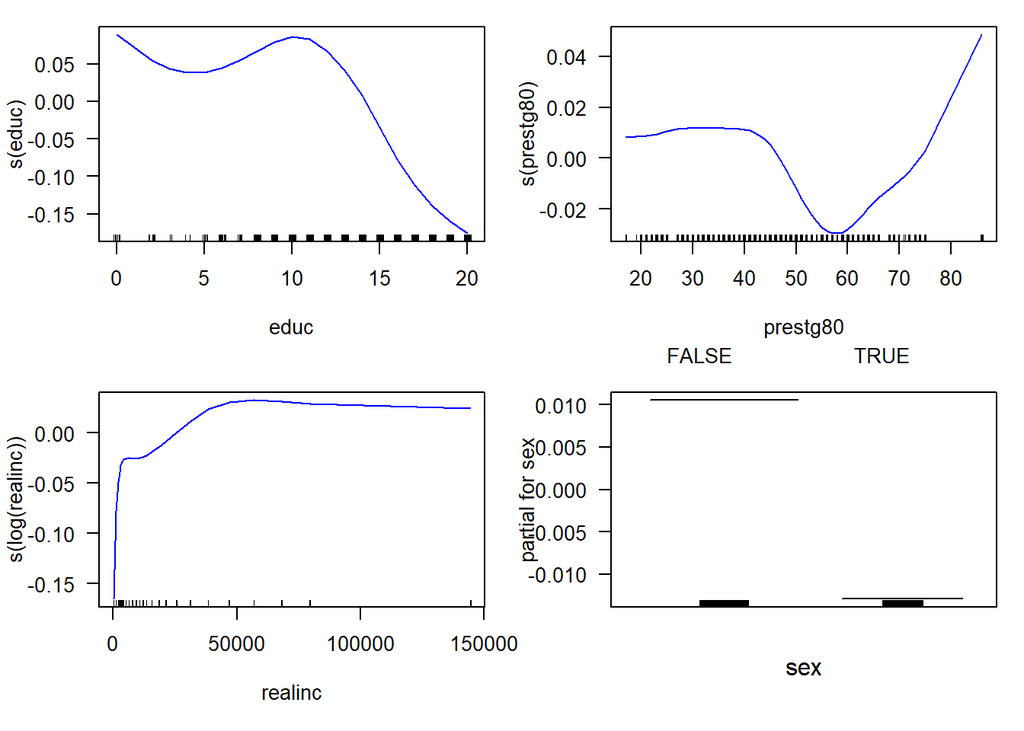

```r
# make Plots

par(mfrow=c(2,2), las = 1, mar = c(5,4,1,1) + .1)

plot(gam_train,col="blue")
```

Since our predictors are non-linear with the outcome, we can take advantage of GAM, because GAM allow us to fit a non-linear fj to each Xj and the non-linear fits can potentially make more accurate predictions for the response Y . The average SSR is smaller in the training data (0.2304) than in the testing data (0.2311), which is to be expected given that the parameters underlying the predictions are estimated from the training data in order to minimize the SSR.

```r
# Predicting the gam model in the training data
Yhat_gam00 <- predict(gam_train)
mean( (training$polviews - Yhat_gam00) ^ 2 )
```

```
## [1] 0.2303641
```

```r
# Predicting the gam model in the testing data
Yhat_gam <- predict(gam_train, newdata = testing)
mean( (testing$polviews - Yhat_gam) ^ 2 )
```

```
## [1] 0.2310977
```

I also compared mean squared error for logit + step model with a generalized additive model. The MSE for logit+step was 0.9923 Compared to the logit model, the GAM provides a better fit in terms of least squares.

```r
MSE_logit2 <- mean( (testing$polviews -
                    predict(logit2, newdata = testing)) ^ 2)
MSE_logit2
```

```
## [1] 0.9922816
```

## Expended model 2: Tree-based methods

I chose to use tree-based models(plain tree,bagging, random forest, and bart machine) for classification to investigate they fit better than Logit/LDA/QDA/GAM models.

**(plain tree + prune.tree)**

The plot shows a classification tree for predicting the moderate political views, based on the number of years of education. As we can see, only one variable (education) is used in tree construction, and the number of terminal nodes is 2.

The plain tree approach is virtually guaranteed to overfit in the training data and predict poorly in the testing data. To compensate, I utilized a *tree pruning* after the initial algorithm has terminated to choose the best parts of the original tree. However, in this case, the _tree pruning did not result in minimizing mean squared errors.

```r
training$polviews <- as.factor(training$polviews)
testing$polviews <- as.factor(testing$polviews)
```

```r
stopifnot(require(tree))
tree_model <- tree(polviews ~ ., data = training)
summary(tree_model)
```

```
##
## Classification tree:
## tree(formula = polviews ~ ., data = training)
## Variables actually used in tree construction:
## [1] "educ"
## Number of terminal nodes:  2
## Residual mean deviance:  1.315 = 2335 / 1776
## Misclassification error rate: 0.3898 = 693 / 1778
```

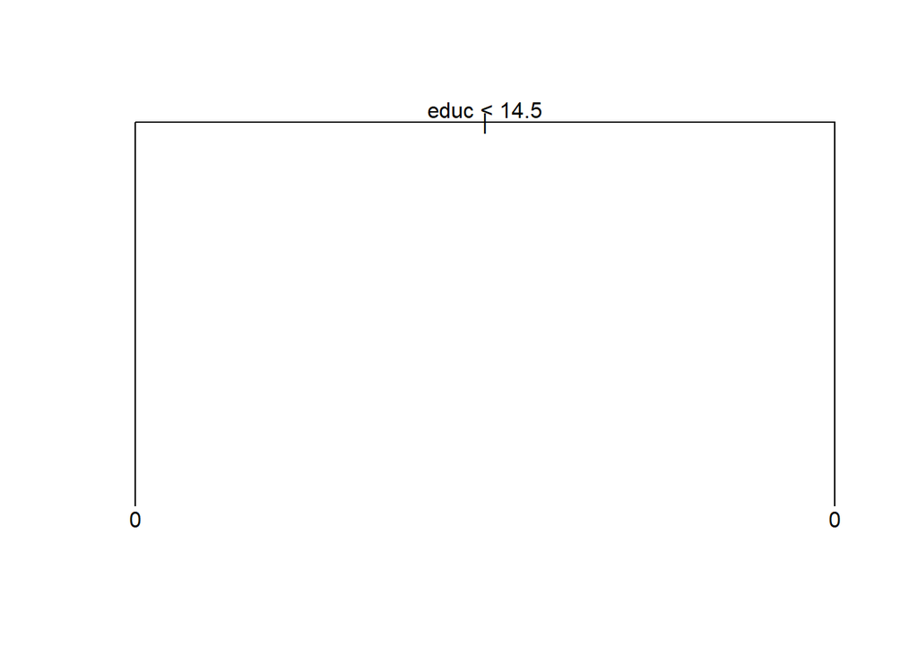

```r
plot(tree_model)
text(tree_model, pretty = 0)
```

```r
new_tree <- cv.tree(tree_model, FUN = prune.misclass)
new_tree$dev
```

```
## [1] 693 693
```

```r
best_tree <- prune.tree(tree_model, best = 2)
summary(best_tree)
```

```
##
## Classification tree:
## tree(formula = polviews ~ ., data = training)
## Variables actually used in tree construction:
## [1] "educ"
## Number of terminal nodes:  2
## Residual mean deviance:  1.315 = 2335 / 1776
## Misclassification error rate: 0.3898 = 693 / 1778
```

```r
tree_hat <- predict(best_tree, newdata = testing, type = "class")
table(testing$polviews, tree_hat)
```

```
##    tree_hat
##        0    1
##   0 1107    0
##   1  671    0
```

```r
mean(testing$polviews == tree_hat)
```

```
## [1] 0.6226097
```

**(bagging)**

```r
stopifnot(require(randomForest))
bagging <- randomForest(polviews ~ ., data = training, mtry = 10, importance = TRUE)
```

As shown in the plot, we can immediately see that *education* is the most important factor in terms of the mean decrease in accuracy, and *age/occupational prestige/income/education* are the most important factor in terms of gini index. (The mean decrease in the Gini coefficient is a measure of how each variable contributes to the homogeneity of the nodes and leaves in the resulting random forest)

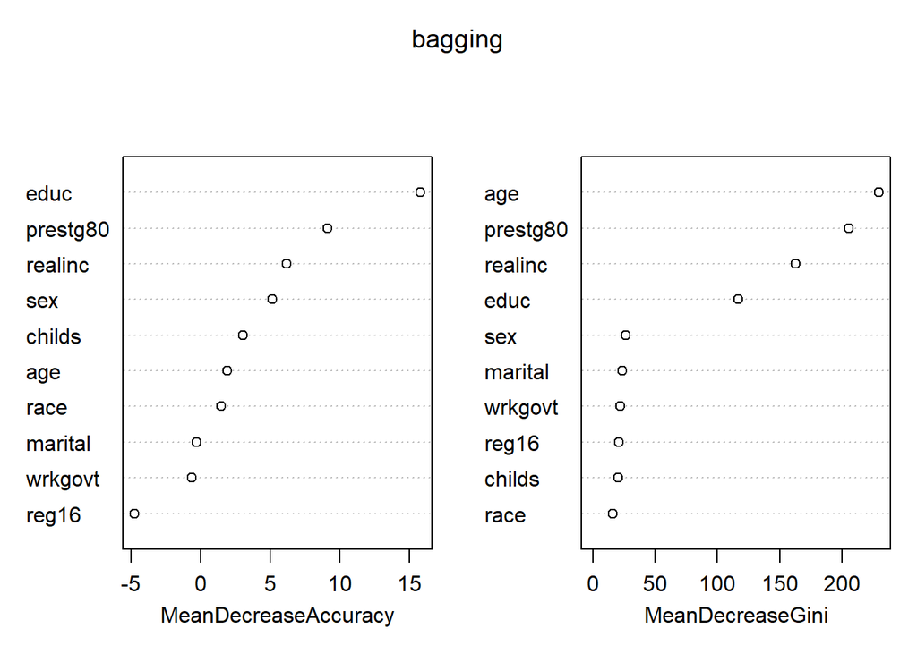

```r
varImpPlot(bagging)
```

Bagging shows 57.59% of correct predictions in the testing data.

```r
bagging_hat <- predict(bagging, newdata = testing, type="response")
table(testing$polviews, bagging_hat)
```

```
##    bagging_hat
##       0   1
##   0 808 299
##   1 455 216
```

```r
mean(testing$polviews == bagging_hat)
```

```
## [1] 0.575928
```

**(random forest )**

The varImpPlot()shows result similar to bagging. Noticeably, importance of *childs/sex/occupational prestige* is degreased when using random forest.

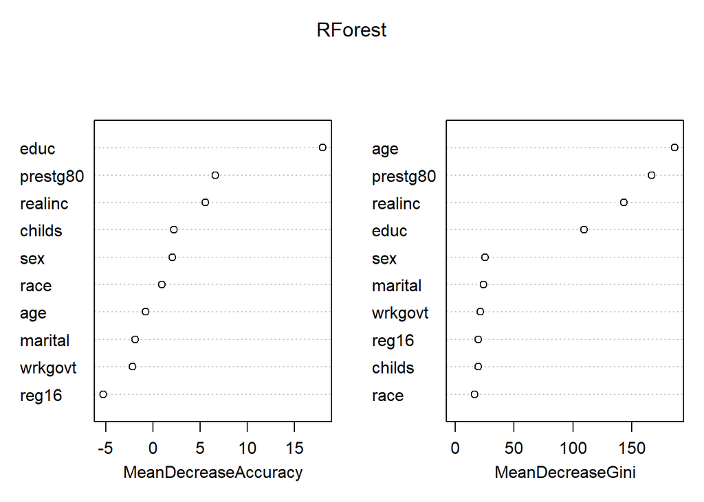

```r
stopifnot(require(randomForest))

RForest <- randomForest(polviews ~ ., data = training, importance = TRUE)

varImpPlot(RForest)
```

```r
RForest_hat <- predict(RForest, newdata = testing, type="response")
table(testing$polviews, RForest_hat)
```

```
##    RForest_hat
##       0   1
##   0 886 221
##   1 508 163
```

```r
mean(testing$polviews == RForest_hat)
```

```
## [1] 0.5899888
```

**(bart machine)**

```r
options( java.parameters = "-Xmx4g" )
stopifnot(require(bartMachine))
```

```
## Welcome to bartMachine v1.2.3! You have 3.82GB memory available.
##
## If you run out of memory, restart R, and use e.g.
## 'options(java.parameters = "-Xmx5g")' for 5GB of RAM before you call
## 'library(bartMachine)'.
```

```r
set_bart_machine_num_cores(parallel::detectCores())
```

```
## bartMachine now using 8 cores.
```

```r
bart <- bartMachine(X = training[,c(2,3,4,5,6,7,8,9,10,11)], y = training$polviews, mem_cache_for_speed = FALSE)
```

[output not shown]

```r
bart
```

```
## bartMachine v1.2.3 for classification
##
## training data n = 1778 and p = 16
## built in 7 secs on 8 cores, 50 trees, 250 burn-in and 1000 post. samples
##
## confusion matrix:
##
##            predicted 0 predicted 1 model errors
## actual 0      1031.000      54.000        0.050
## actual 1       600.000      93.000        0.866
## use errors       0.368       0.367        0.368
```

```r
bart_hat <- bart_predict_for_test_data(bart_machine = bart, Xtest = testing[,c(2,3,4,5,6,7,8,9,10,11)], ytest = testing$polviews)

table(testing$polviews, bart_hat$y_hat)
```

```
##
##        0    1
##   0 1031   76
##   1  619   52
```

```r
mean(testing$polviews == bart_hat$y_hat)
```

```
## [1] 0.6091114
```

## Conclusion

**(Appendix: Description of the outcome and predictors)**

```r
library(psych)
describe(d)
```

```
##          vars    n     mean       sd  median  trimmed      mad    min
## polviews    1 3556     0.38     0.49     0.0     0.35     0.00   0.00
## educ        2 3556    13.54     3.11    13.0    13.63     1.48   0.00
## prestg80    3 3556    44.41    14.08    44.0    43.81    14.83  17.00
## realinc     4 3556 34715.27 32822.09 25582.5 28677.44 20017.88 284.25
## age         5 3556    46.78    16.47    45.0    45.85    17.79  18.00
## sex*        6 3556     1.46     0.50     1.0     1.45     0.00   1.00
## race*       7 3556     1.12     0.32     1.0     1.02     0.00   1.00
## marital*    8 3556     1.51     0.50     2.0     1.51     0.00   1.00
## childs*     9 3556     1.27     0.45     1.0     1.22     0.00   1.00
## wrkgovt*   10 3556     1.19     0.39     1.0     1.11     0.00   1.00
## reg16*     11 3556     1.17     0.37     1.0     1.09     0.00   1.00
##               max    range  skew kurtosis     se
## polviews      1.0      1.0  0.48    -1.77   0.01
## educ         20.0     20.0 -0.65     2.03   0.05
## prestg80     86.0     69.0  0.39    -0.49   0.24
## realinc  144502.7 144218.5  2.06     4.34 550.41
## age          89.0     71.0  0.43    -0.51   0.28
## sex*          2.0      1.0  0.15    -1.98   0.01
## race*         2.0      1.0  2.41     3.80   0.01
## marital*      2.0      1.0 -0.04    -2.00   0.01
## childs*       2.0      1.0  1.01    -0.98   0.01
## wrkgovt*      2.0      1.0  1.57     0.46   0.01
## reg16*        2.0      1.0  1.77     1.15   0.01
```